# PD5

Hanna Zdulska

12/5/2019

# 1 Wprowadzenie

Dawno, dawno temu w odległej pracy domowej poprawialiśmy złe wykresy i argumentowaliśmy dlaczego są mylące, bądź wręcz manipulujące. Jako że warto być ekologicznym, to w tej pracy zastosuję recykling i do analizy percepcji odbiorców zastosujemy wykres analizowany w PD3.

Jako materiał do analizy użyłam [tweeta](https://twitter.com/C_Kazmierczak/status/1191015667908128768) autorstwa Cezarego Kaźmierczaka (@C_Kazmierczak).

Ankieta jest dostępna tutaj: [link](https://forms.gle/azHisAQfwTuxxoWh9)

Na pierwszej stronie odbiorca poproszony jest o przyjrzenie się wykresowni przez 10-15, a następnie udzielenie odpowiedzi na następujące pytania:

- Jaki (procentowy) spadek zabitych nastąpił między pikiem(maksymalną wartością) a rokiem 2018?
- W którym roku wystąpiła największa liczba zabitych?

Następnie ponownie wyświetlony jest wykres wraz z pytaniami:

- Napisz co twoim zdaniem przedstawia wykres
- Czy oś pozioma(z datami) jest czytelna?

# 2 Dane

Przyjrzyjmy się teraz otrzymanym wynikom.

```r
dat <- read.csv("./dane.csv")
colnames(dat) <- c("time", "proc", "rok", "wykres", "czytelny")
czy_procent <- function(x){
        flag <- (substr(x, nchar(x), nchar(x)) == "%")
        return(flag)
}
```

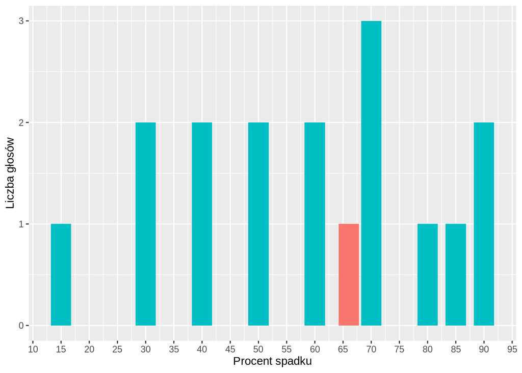

```r
#Odsiejmy procenty
v <- ifelse(czy_procent(dat$proc), substr(dat$proc, nchar(dat$proc)-2, nchar(dat$proc) - 1), dat$proc)

#usuniemy również odpowiedzi w stylu "nie wiem"
v <- as.numeric(v[nchar(v) <= 2])
kol2 <- rep("#00BFC4", 10)
kol2[6] <- "#F8766D"
ggplot(as.data.frame(v), aes(x = v)) +
        geom_histogram(stat = "count", fill =kol2, bins = 20) +
        scale_x_continuous(breaks = seq(0,100,5)) +
        xlab("Procent spadku") +
        ylab("Liczba głosów")
```

Jak widać trudno było czytelnikom ocenić jaka była faktyczna różnica. Fakt, iż pytanie zostało sforumowane w sposób nieintuicyjny (procentowy spadek - kto myśli o takich pojęciach przy oglądaniu wykresu?)

Jak poradzili sobie z rokiem?

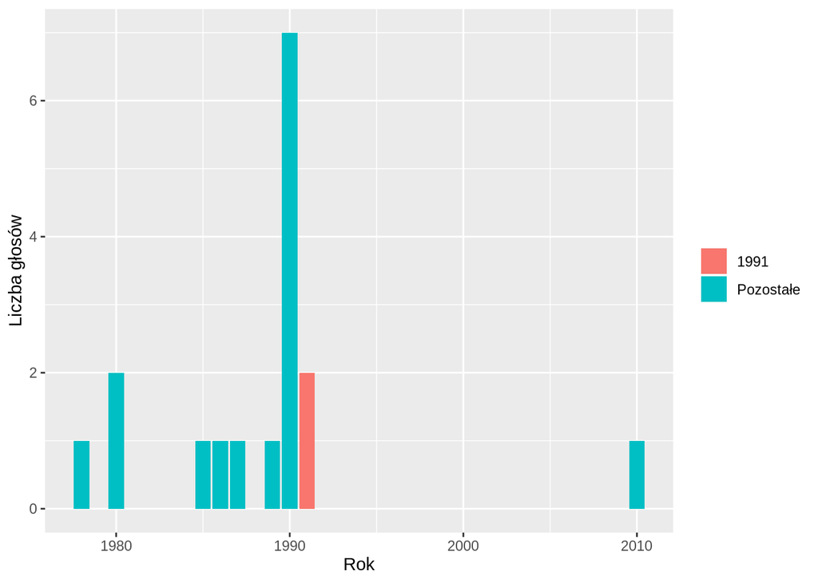

```r
# odsiejmy niepewne wyniki
v <- as.numeric(dat$rok[nchar(dat$rok) == 4])
ggplot(as.data.frame(v), aes(x = v, fill = ifelse(v == 1991, "1991", "Pozostałe"))) + geom_histogram(stat = "count") + theme(legend.title = element_blank()) + xlab("Rok") + ylab("Liczba głosów")
```

Jak widać pomimo braku osi, więkoszość osób była w przybliżeniu poprawnie określić rok - pik nastąpił w 1991, wyniki oscylowały wokół 1990. Nie mniej jednak w pytaniu o czytelność osi X, większość osób odpowiedziała, iż nie była ona czytelna, co daje prosty wniosek - pomimo nieczytelności odbiorcy byli w stanie poprawnie określić rok.

[figure not shown]

```r
dat2 <- dat[nchar(dat$rok) == 4,]
dat2$rok <- v
ggplot(as.data.frame(dat2), aes(y = rok,x = czytelny, color = czytelny)) + geom_jitter(width = 0.3, height = 0) + scale_color_discrete(name = "Czy oś Y jest czytelna?", labels = c("Nie (63,6%)", "Tak (27,3%)", "Trudno powiedzieć (9,1%)"))
```

Przy tak małej próbie(22 osoby) niestety trudno stwierdzić czy istnieje korelacja pomiędzy uważaniem osi za nieczytelną a poprawnym określeniem piku.

# 3 Ale o czym jest ten wykres?

W ankiecie padło również pytanie na które każdy wykres powinien jasno odpowiadać - o czym właściwie jest.

```r
knitr::kable(dat$wykres)
```

| x |
| --- |
| Właściwie to nie mam pojęcia |
| Wykres zależnośxi zabitych od roku |
| Zmiany liczby zabitych na przestrzeni lat 1975-2018 |
| Liczbę zabitych osób w poszczególnych latach |
| Liczbę osób zabitych w poszczególnych latach |
| Ilość Ludzi zabitych w latach 1975-2018 |
| Ilość osob zabitych w poszczególnych latch |
| osoby zabite bezpośrednio przez napastnika, prawdopodobnie należące do węższej grupy np.osoby pewnej rasy, orientacji lub w jakimś wieku |
| Liczba zabitych w danym roku |
| Zabitych |
| Ilość zabitych w każdym roku |
| Liczba zabitych mieszkańców na danym terenie |
| Liczba zabitych w poszczególnych latach (gdzie i dlaczego?) |
| Ilość osób zabitych w danym roku |
| Ilość ludzi zabitych w jakieś określonej grupie w danym roku |
| liczbę zgonów |
| Ilość zabitych ludzi gdzieś |
| Ilość zabitych względem rzędu nieczytelnych liczb |
| wykres przedstawia ilość osób zabitych w danym roku |
| Liczbę zabitych w każdym roku od 1975 |
| Stosunek zabitych do czasu kiedy to się stało |
| Zaleznosc ilosci zabitych do roku |

Większość ludzi bezproblemowo odczytała, iż wykres przedstawia zabitych w danych latach. Jest to dość oczywiste, jednak wykres nie daje ani źródeł, ani nawet nie próbuje wyjaśnić co bądź kto zabił. Tylko nieduży odsetek osób - tylko trzy osoby podjęły sie próby doprecyzowania przyczyny zgonów i kwestionowania danych:

> Liczba zabitych mieszkańców na danym terenie

> osoby zabite bezpośrednio przez napastnika, prawdopodobnie należące do węższej grupy np.osoby pewnej rasy, orientacji lub w jakimś wieku

> Ilość zabitych ludzi gdzieś

Jedna postanowiła zadać pytania, na które autor wykresu nie odpowiada:

> Liczba zabitych w poszczególnych latach (gdzie i dlaczego?)

# 4 Podsumowanie

Na zakończenie przytoczmy jedną z odpowiedzi na pytanie co przedstawia wykres:"

> Właściwie to nie mam pojęcia